# Supplementary code to reproduce the numerical results in Di Caterina and Kosmidis (2019)

Claudia Di Caterina, [Ioannis Kosmidis](http://www.ucl.ac.uk/~ucakiko/)

8 March 2019

# Workspace preparation

This document provides R (R Core Team, 2017) code to reproduce the results in the manuscript ‘Location-adjusted Wald statistics for scalar parameters’ by Di Caterina and Kosmidis (2019).

This script assumes that the current working directory has the sub-directories `code`, `results` and `lesion data` as provided in the supplementary material.

```r
path <- "."
code_path <- paste(path, "code", sep = "/")
results_path <- paste(path, "results", sep = "/")
lesions_path <- paste(path, "lesion data", sep = "/")
```

The contents of the directories are as follows

```r
dir(code_path)
# [1] "babies_simulation.R"        "babies_timings.R"
# [3] "brains_case_study.R"        "clotting_simulation.R"
# [5] "dyslexia_simulation.R"      "logodds_functions.R"
# [7] "meta_analysis_simulation.R" "overlay2_nifti.R"
dir(results_path)
# [1] "babies_simulation.rda"        "babies_times.rda"
# [3] "brains_case_study.rda"        "clotting_simulation.rda"
# [5] "dyslexia_simulation.rda"      "meta_analysis_simulation.rda"
dir(lesions_path)
# [1] "data_demo.dat" "images"
```

First, make sure that you have the latest version of the **waldi** R package installed.

```r
waldi_version <- try(packageVersion("waldi"), silent = TRUE)
if (inherits(waldi_version, "try-error")) {
    devtools::install_github("ikosmidis/waldi")
}
```

The following code chunk loads the required packages

```r
library("waldi")
library("oro.nifti")
library("boot")
library("plyr")
library("plotrix")
library("dplyr")
library("survival")
library("cond")
library("lmtest")
library("betareg")
library("enrichwith")
library("brglm2")
library("ggplot2")
library("gridExtra")
library("colorspace")
```

# Pre-saved R image files

Some of the code-chunks below load objects from the pre-saved R image files in the results directory. These image files are the outputs of the scripts `babies_simulation.R`, `babies_timings.R`, `brains_case_study.R`, `clotting_simulation.R`, `dyslexia_simulation.R`, `meta_analysis_simulation.R`.

# Table 1

```r
data("ReadingSkills", package = "betareg")
## maximum likelihood estimates and corresponding 95\% Wald confidence intervals
rs_beta_ml <- betareg(accuracy ~ dyslexia * iq | dyslexia + iq,
                      data = ReadingSkills, type = "ML", hessian = FALSE)
rs_summary_ml <- coef(summary(rs_beta_ml))
rs_ml_estimates <- do.call("rbind", lapply(rs_summary_ml,
                                           function(z) z[, c("Estimate", "Std. Error")]))
rs_ml_cis <- confint(rs_beta_ml)
## bias corrected fit and corresponding 95\% Wald confidence intervals
rs_beta_br <- update(rs_beta_ml, type = "BR")
rs_summary_br <- coef(summary(rs_beta_br))
rs_br_estimates <- do.call("rbind", lapply(rs_summary_br,
                                           function(z) z[, c("Estimate", "Std. Error")]))
rs_br_cis <- confint(rs_beta_br)
round(cbind(rs_ml_estimates, rs_br_estimates, rs_ml_cis, rs_br_cis), 3)
#             Estimate Std. Error Estimate Std. Error  2.5 % 97.5 %  2.5 % 97.5 %
# (Intercept)    1.123      0.143    1.114      0.148  0.843  1.403  0.824  1.405
# dyslexia      -0.742      0.143   -0.734      0.148 -1.021 -0.462 -1.024 -0.444
# iq             0.486      0.133    0.441      0.141  0.225  0.747  0.165  0.717
# dyslexia:iq   -0.581      0.133   -0.532      0.140 -0.841 -0.321 -0.807 -0.257
# (Intercept)    3.304      0.223    3.092      0.225  2.868  3.741  2.652  3.533
# dyslexia       1.747      0.262    1.654      0.264  1.232  2.261  1.138  2.171
# iq             1.229      0.267    1.048      0.271  0.705  1.753  0.518  1.578
```

# Table 2

`dyslexia_simulation.rda` contains the outputs of `dyslexia_simulation.R` in ./code, which replicates the simulation study described in Example 1.1 of Di Caterina and Kosmidis (2019)

```r
load(paste(results_path, paste0("dyslexia_simulation.rda"), sep = "/"))
rs_coverage <- results %>%
    filter(parameter %in% c("dyslexia", "iq", "dyslexia:iq", "(phi)_dyslexia",
                            "(phi)_iq")) %>%
    filter(statistic %in% c("ml", "br", "ml_cor", "br_cor",
                            "ml_stud", "ml_cor_stud", "br_stud", "br_cor_stud",
                            "ml_cor_ses_cor", "br_cor_ses_cor")) %>%
    mutate(parameter = recode(parameter,
                              "dyslexia" = 2, "iq" = 3, "dyslexia:iq" = 4,
                              "(phi)_dyslexia" = 6, "(phi)_iq" = 7)) %>%
    mutate(level = 100 * level) %>%
    group_by(level, statistic, parameter) %>%
    summarize(coverage = round(mean(cover, na.rm = TRUE) * 100, 1)) %>%
    as.data.frame() %>%
    reshape(idvar = c("statistic", "parameter"), v.names = "coverage",
            timevar = "level",
            direction = "wide")
rs_coverage %>% filter(statistic %in% c("ml", "br")) %>%
    select(statistic, parameter, coverage.90, coverage.95, coverage.99)
#    statistic parameter coverage.90 coverage.95 coverage.99
# 1         br         2        88.1        93.4        98.2
# 2         br         3        87.2        92.9        98.0
# 3         br         4        87.3        92.9        98.0
# 4         br         6        83.8        90.2        96.7
# 5         br         7        82.7        89.2        96.1
# 6         ml         2        86.9        92.4        97.7
# 7         ml         3        84.8        91.0        97.1
# 8         ml         4        85.0        91.2        97.2
# 9         ml         6        82.4        89.1        96.1
# 10        ml         7        79.1        86.0        94.4
```

# Figure 1

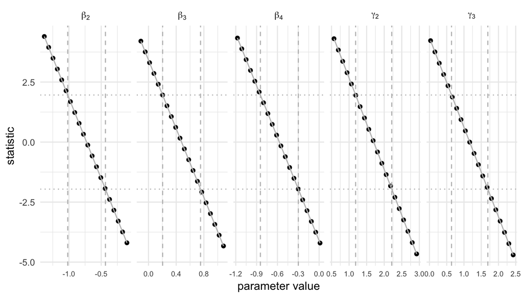

```r
rs_cor_ml_cis <- waldi_confint(rs_beta_ml, level = 0.95, adjust = TRUE)
interpolation <- waldi_confint(rs_beta_ml, level = 0.95,
                               which = rownames(rs_cor_ml_cis),
                               adjust = TRUE,
                               return_values = TRUE,
                               length = 20)
intervals <- data.frame(low = rs_cor_ml_cis[, 1],
                        upp = rs_cor_ml_cis[, 2],
                        parameter = rownames(rs_cor_ml_cis))
interpolation <- interpolation %>%
    filter(!(parameter %in% c("(Intercept)", "(phi)_(Intercept)"))) %>%
    mutate(parameter = recode(parameter,
                              "dyslexia" = "beta[2]",
                              "iq" = "beta[3]",
                              "dyslexia:iq" = "beta[4]",
                              "(phi)_dyslexia" = "gamma[2]",
                              "(phi)_iq" = "gamma[3]"))
intervals <- intervals %>%
    filter(!(parameter %in% c("(Intercept)", "(phi)_(Intercept)"))) %>%
    mutate(parameter = recode(parameter,
                              "dyslexia" = "beta[2]",
                              "iq" = "beta[3]",
                              "dyslexia:iq" = "beta[4]",
                              "(phi)_dyslexia" = "gamma[2]",
                              "(phi)_iq" = "gamma[3]"))
ggplot(interpolation) +
    geom_point(aes(x = grid, y = value)) +
    geom_line(aes(x = grid, y = value), col = "grey") +
    geom_hline(aes(yintercept = qnorm(0.975)), col = "grey", lty = 3) +
    geom_hline(aes(yintercept = qnorm(0.025)), col = "grey", lty = 3) +
    geom_vline(data = intervals, aes(xintercept = low), col = "grey", lty = 2) +
    geom_vline(data = intervals, aes(xintercept = upp), col = "grey", lty = 2) +
    facet_grid(~ parameter, scale = "free_x", labeller = "label_parsed") +
    theme_minimal() +
    theme(axis.text.x = element_text(size = 7)) +
    labs(x = "parameter value", y = "statistic")
```

# Table 3

```r
## Confidence intervals based on the location-adjusted Wald statistic
rs_cor_ml_cis <- waldi_confint(rs_beta_ml, level = 0.95, adjust = TRUE, parallel = FALSE)
rs_cor_br_cis <- waldi_confint(rs_beta_br, level = 0.95, adjust = TRUE, parallel = FALSE)
## Studentized bootstrap intervals
set.seed(123)
quantiles_ml <- dyslexia_bootstrap(rs_beta_ml, R = 500, ncores = 1)$quantiles
quantiles_br <- dyslexia_bootstrap(rs_beta_br, R = 500, ncores = 1)$quantiles
rs_ml_stud_cis <- waldi_confint(rs_beta_ml, adjust = FALSE, parallel = FALSE,
                                quantiles = quantiles_ml$zstat[, c("0.025", "0.975")])
rs_br_stud_cis <- waldi_confint(rs_beta_br, adjust = FALSE, parallel = FALSE,
                                quantiles = quantiles_br$zstat[, c("0.025", "0.975")])
rs_cor_ml_stud_cis <- waldi_confint(rs_beta_ml, adjust = TRUE, parallel = FALSE,
                      quantiles = quantiles_ml$zstat_cor[, c("0.025", "0.975")])
rs_cor_br_stud_cis <- waldi_confint(rs_beta_br, adjust = TRUE, parallel = FALSE,
                      quantiles = quantiles_br$zstat_cor[, c("0.025", "0.975")])

round(rbind(cbind(rs_cor_ml_cis, rs_cor_br_cis),
            cbind(rs_cor_ml_stud_cis, rs_cor_br_stud_cis)), 3)
#                    2.5 % 97.5 %  2.5 % 97.5 %
# (Intercept)        0.816  1.400  0.827  1.411
# dyslexia          -1.019 -0.435 -1.031 -0.446
# iq                 0.204  0.752  0.165  0.719
# dyslexia:iq       -0.845 -0.299 -0.809 -0.257
# (phi)_(Intercept)  2.689  3.564  2.652  3.532
# (phi)_dyslexia     1.186  2.214  1.134  2.169
# (phi)_iq           0.639  1.691  0.513  1.574
# (Intercept)        0.812  1.420  0.830  1.481
# dyslexia          -1.059 -0.442 -1.091 -0.440
# iq                 0.171  0.792  0.159  0.758
# dyslexia:iq       -0.871 -0.268 -0.853 -0.264
# (phi)_(Intercept)  2.709  3.680  2.654  3.682
# (phi)_dyslexia     1.112  2.303  1.040  2.241
# (phi)_iq           0.565  1.835  0.394  1.769
rs_coverage %>% filter(statistic %in% c("ml_cor", "br_cor")) %>%
    select(statistic, parameter, coverage.90, coverage.95, coverage.99)
#    statistic parameter coverage.90 coverage.95 coverage.99
# 1     br_cor         2        88.3        93.5        98.3
# 2     br_cor         3        87.3        93.0        98.0
# 3     br_cor         4        87.5        93.0        98.0
# 4     br_cor         6        83.9        90.3        96.8
# 5     br_cor         7        82.7        89.2        96.2
# 6     ml_cor         2        88.5        93.7        98.4
# 7     ml_cor         3        87.1        92.8        98.0
# 8     ml_cor         4        87.2        92.8        98.0
# 9     ml_cor         6        83.5        90.0        96.6
# 10    ml_cor         7        81.8        88.6        95.7
rs_coverage %>% filter(statistic %in% c("ml_cor_stud", "br_cor_stud")) %>%
    select(statistic, parameter, coverage.90, coverage.95, coverage.99)
#      statistic parameter coverage.90 coverage.95 coverage.99
# 1  br_cor_stud         2        89.4        94.6        98.6
# 2  br_cor_stud         3        89.4        94.5        98.5
# 3  br_cor_stud         4        89.5        94.4        98.6
# 4  br_cor_stud         6        90.1        94.9        98.8
# 5  br_cor_stud         7        90.5        95.1        98.8
# 6  ml_cor_stud         2        89.5        94.5        98.7
# 7  ml_cor_stud         3        89.2        94.3        98.5
# 8  ml_cor_stud         4        89.3        94.3        98.5
# 9  ml_cor_stud         6        89.9        94.7        98.7
# 10 ml_cor_stud         7        90.1        94.9        98.7
```

The following chunk of code reproduces the times for the computation of the confidence intervals reported in Section 6.

```r
## Intervals based on the location-adjusted Wald statistic
system.time({
    waldi_confint(rs_beta_ml, adjust = TRUE, parallel = FALSE, length = 5)
})
#    user  system elapsed
#   1.956   0.022   1.978
simu_fun <- get_simulate_function(rs_beta_ml)
generate_dyslexia <- function(data, mle) {
    simu_fun(mle)
}
stat <- function(data, psi) {
    temp <- ReadingSkills
    temp$accuracy <- data
    temp_fit <- try(update(rs_beta_ml, data = temp))
    if (inherits(temp_fit, "try-error")) {
        rep(NA, 7)
    }
    else {
        waldi(temp_fit, null = psi, adjust = TRUE)
    }
}
## Studentized bootstrap intervals
system.time({
    stats <- boot(ReadingSkills$accuracy, statistic = stat,
                  R = 500, sim = "parametric", ran.gen = generate_dyslexia,
                  mle = coef(rs_beta_ml), psi = coef(rs_beta_ml), ncpus = 1)$t
    quant <- t(apply(stats, 2, quantile, probs = c(0.025, 0.975), na.rm = TRUE))
    waldi_confint(rs_beta_br, adjust = TRUE, parallel = FALSE,
                  quantiles = quant)
})
#    user  system elapsed
# 191.531   1.992 193.639
```

# Figure 2

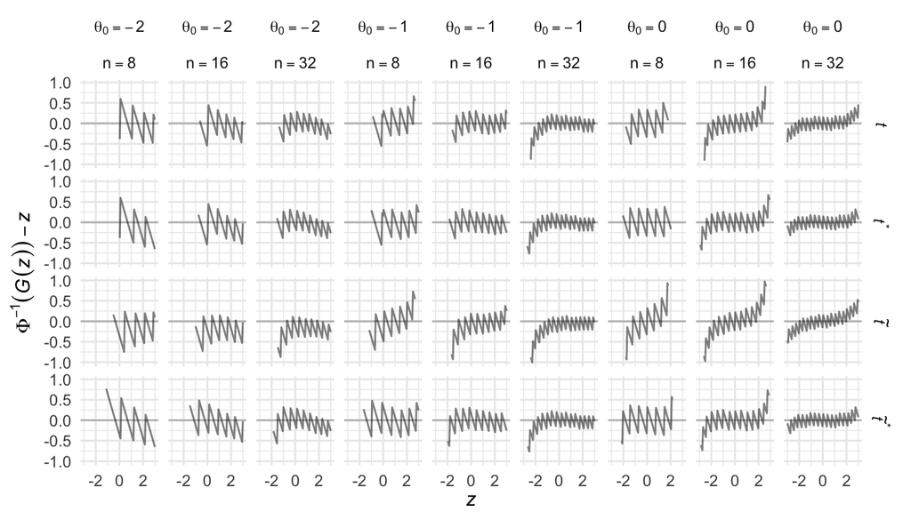

```r
source(paste0(code_path, "/", "logodds_functions.R"))
## Distribution of the statistic against normal
settings <- expand.grid(m = c(8, 16, 32), theta0 = c(-2, -1, 0))
plot_data <- NULL
for (j in seq.int(nrow(settings))) {
    setting <- settings[j, ]
    z <- seq(-3, 3, length = 100)
    dat <- t(sapply(z, dist_function, n = setting$m, theta0 = setting$theta0))
    dd <- stack(as.data.frame(dat))
    dd$z <- z
    names(dd) <- c("prob", "method", "z")
    dd$theta0 <- setting$theta0
    dd$m <- setting$m
    plot_data <- rbind(plot_data, dd)
}
plot_data$theta0 <- paste0("theta[0] == ", plot_data$theta0)
plot_data$theta0 <- factor(plot_data$theta0, levels = unique(plot_data$theta0),
                           ordered = TRUE)
plot_data$m <- paste0("n == ", plot_data$m)
plot_data$m <- factor(plot_data$m, levels = unique(plot_data$m), ordered = TRUE)
plot_data$method <- factor(plot_data$method, levels = c("ml", "a_ml", "br", "a_br"),
                           ordered = TRUE)
plot_data$method <- recode(plot_data$method,
                           "ml" = "italic(t)",
                           "a_ml" = "italic(t)^{'*'}",
                           "br" = "tilde(italic(t))",
                           "a_br" = "tilde(italic(t))^{'*'}")
ggplot(plot_data) +
    geom_abline(aes(intercept = 0, slope = 0), col = "grey") +
    geom_line(aes(z, qnorm(prob) - z), alpha = 0.5) +
    facet_grid(method ~ theta0 + m, label = label_parsed) +
    theme_minimal() +
    labs(y = expression(paste(Phi^list(-1),(italic(G)(italic(z))) - italic(z))),
         x = expression(italic(z))) +
    theme(text=element_text(size = 11))
```

# Coverage and length of confidence intervals for a binomial proportion

This section provides evidence for the stated coverage and expected length properties of confidence intervals for a binomial proportion in Section 8 of the main text. The code chunk below computes and visualises the coverage and expected length of the $95\%$ confindence intervals $\bar{y} \pm z_{0.975} \sqrt{\bar{y} (1 - \bar{y})/n}$ (Wald), $\tilde{p} \pm z_{0.975} \sqrt{\tilde{p} (1 - \tilde{p})/(n + 4)}$, where $\tilde{p} = (\sum{y_i} + 2)/(n + 4)$ (Agresti-Coull; Agresti and Coull, 1998; Agresti and Caffo, 2000), and the intervals based on the transformation of the endpoints of the confidence intervals for the log-odds based on $\tilde{t}^*$.

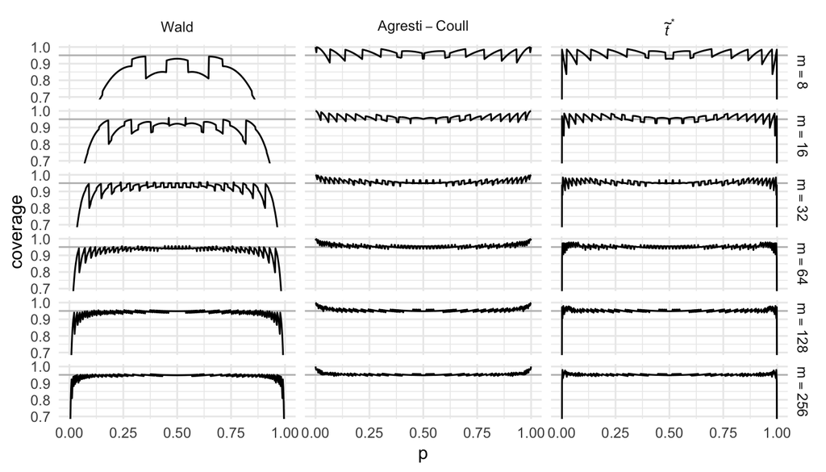

```r
probs <- seq(1e-08, 1 - 1e-08, length = 500)
df <- ddply(data.frame(m = c(8, 16, 32, 64, 128, 256)), ~ m, function(x) {
    m <- x$m
    cis <- compute_cis(m, level = 0.95)
    cc <- lapply(probs, function(pp) cover_ci_prop(n = m, p = pp, level = 0.95, cis = cis))
    do.call("rbind", cc)
})
df$m <- factor(paste("m ==", df$m), levels = paste("m ==", sort(unique(df$m))),
               ordered = TRUE)
df$method <- factor(df$method, levels = c("wald", "ac", "a_br", "ml", "a_ml", "br"),
                    ordered = TRUE)
df$method <- recode(df$method,
                    "wald" = "Wald",
                    "ml" = "italic(t)[trans]",
                    "a_ml" = "italic(t)^*[trans]",
                    "br" = "tilde(italic(t))[trans]",
                    "a_br" = "tilde(italic(t))^{'*'}",
                    "ac" = "Agresti-Coull")
## coverage
ggplot(df %>% filter(method %in% c("Wald", "Agresti-Coull", "tilde(italic(t))^{'*'}"))) +
    geom_hline(aes(yintercept = 0.95), col = "grey") +
    geom_line(aes(x = p, y = coverage)) +
    facet_grid(m ~ method, label = label_parsed) +
    coord_cartesian(ylim = c(0.7, 1)) +
    theme_minimal()
```

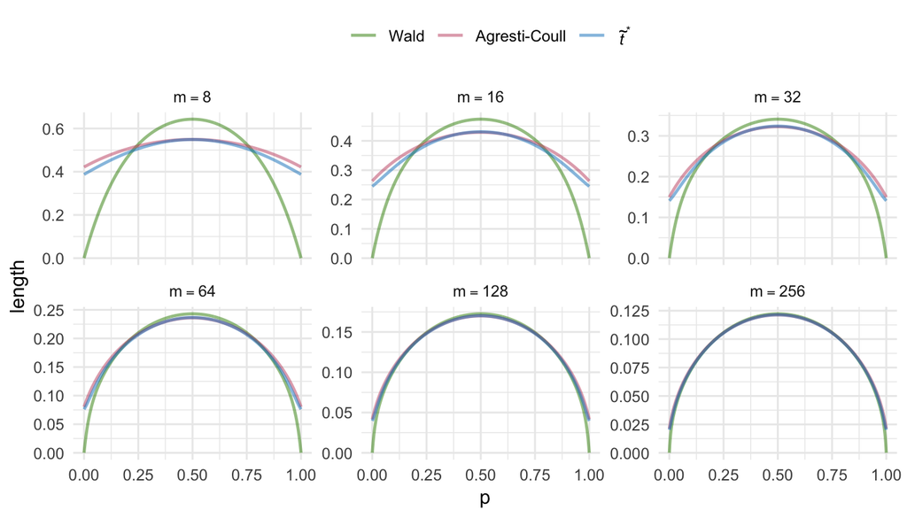

```r
## expected length
ggplot(df %>% filter(method %in% c("Wald", "Agresti-Coull", "tilde(italic(t))^{'*'}"))) +
    geom_line(aes(x = p, y = length, col = method), alpha = 0.5, size = 0.8) +
    facet_wrap(~ m, label = label_parsed, scales = "free_y", ncol = 3) +
    scale_colour_manual(values = c("#328900", "#C54E6D", "#0080C5"),
                        name = "",
                        labels = c("Wald",
                                   "Agresti-Coull",
                                   bquote(tilde(italic(t))^{'*'}))) +
    theme_minimal() +
    theme(legend.position = "top")
```

# Hauck and Donner effect

```r
sapply(28:32, t_ml, n =  32, theta0 = 0)
# [1] 3.640465 3.740749 3.708150 3.379905 0.000000
sapply(28:32, t_adjusted_ml, n =  32, theta0 = 0)
# [1] 3.770481 3.912737 3.955360 3.816022 0.000000
sapply(28:32, t_br, n =  32, theta0 = 0)
# [1] 3.583279 3.712935 3.744298 3.587411 2.884566
sapply(28:32, t_adjusted_br, n =  32, theta0 = 0)
# [1] 3.763721 3.902155 3.935838 3.762302 2.921237
```

# Table 4

```r
## The clotting data set
clotting <- data.frame(
  conc = c(118,58,42,35,27,25,21,19,18,69,35,26,21,18,16,13,12,12),
  u = c(5,10,15,20,30,40,60,80,100, 5,10,15,20,30,40,60,80,100),
  lot = factor(c(rep(1, 9), rep(2, 9))))
## The maximum likelihood fit of the gamma regression model
clotting_ml <- glm(conc ~ log(u)*lot, data = clotting, family = Gamma(link = "log"))
## Maximum likelihood estimates and Wald statistics using maximum likelihood estimator
## of the dispersion parameter
dispersion_ml <- MASS::gamma.dispersion(clotting_ml)
clotting_summary_ml <- summary(clotting_ml, dispersion = dispersion_ml)
clotting_ml_estimates <- coef(clotting_summary_ml)[, c("Estimate", "z value")]
## Reduced-bias estimates and Wald statistics
clotting_summary_rb <- summary(update(clotting_ml, method = "brglmFit"))
## Maximum likelihood estimates and Wald statistics using the moment-based estimator
## of the dispersion parameter
clotting_summary_mom <-  summary(clotting_ml)
dispersion_mom <- clotting_summary_mom$dispersion
clotting_mom_estimates <- coef(clotting_summary_mom)[, c("Estimate", "t value")]
## Location-adjusted Wald statistic
clotting_waldi <- waldi(clotting_ml, null = 0, adjust = TRUE)
round(cbind(c(clotting_ml_estimates[, 1], dispersion_ml, dispersion_mom),
            c(clotting_ml_estimates[, 2], NA, NA),
            c(clotting_mom_estimates[, 2], NA, NA),
            c(clotting_waldi, NA, NA)), 3)
#               [,1]    [,2]    [,3]    [,4]
# (Intercept)  5.503  34.124  29.282  28.953
# log(u)      -0.602 -12.842 -11.020 -10.896
# lot2        -0.584  -2.563  -2.199  -2.173
# log(u):lot2  0.034   0.520   0.446   0.441
#              0.017      NA      NA      NA
#              0.024      NA      NA      NA
```

# Figure 3 including rejection probabilities based on $\tilde{t}$ and $\tilde{t}^*$

`clotting_simulation.rda` below is the output of `clotting_simulation.R` in ./code, which replicates the simulation study described in Section 9.3 of Di Caterina and Kosmidis (2019).

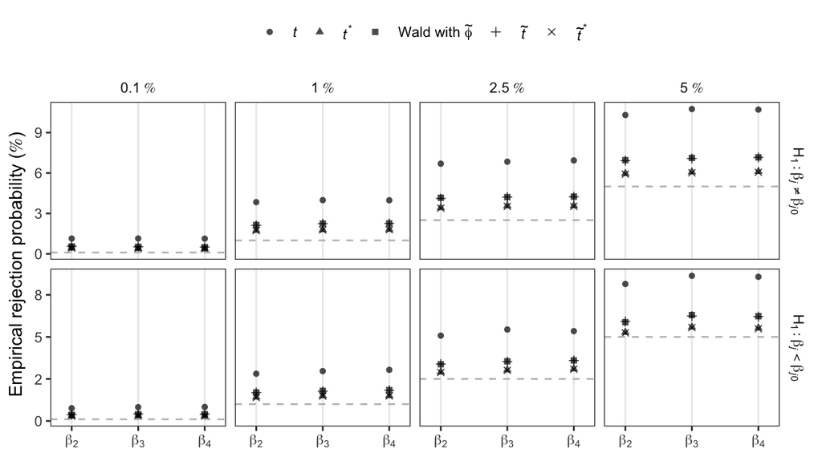

```r
load(paste(results_path, "clotting_simulation.rda", sep = "/"))

## Summary of results
res_statistics <- ldply(res, function(x) x$stats)
res_pvalues <- ldply(res, function(x) x$boot_pvalues)

## Type I error rates
typeI_statistics <- ddply(res_statistics, ~ name + parameter, function(x) {
  levels <- c(0.1, 1, 2.5, 5)/100
  p_value_2sided <- 2 * pnorm(-abs(x$value))
  p_value_left <- pnorm(x$value)
  p_value_right <- 1 - pnorm(x$value)
  rate_2sided <- sapply(levels, function(alpha) mean(p_value_2sided < alpha))
  rate_left <- sapply(levels, function(alpha) mean(p_value_left < alpha))
  rate_right <- sapply(levels, function(alpha) mean(p_value_right < alpha))
  out <- data.frame(
    test = rep(c("2sided", "left", "right"), each = length(levels)),
    typeI = c(rate_2sided, rate_left, rate_right),
    level = rep(levels, times = 3))
  out
})

typeI_pvalues <- ddply(res_pvalues, ~ statistic + parameter, function(x) {
  levels <- c(0.1, 1, 2.5, 5)/100
  rate_2sided <- sapply(levels, function(alpha) mean(x$value[x$type ==
                                'boot_conv_2sided'] < alpha))
  rate_left <- sapply(levels, function(alpha) mean(x$value[x$type ==
                              'boot_conv_left'] < alpha))
  rate_right <- sapply(levels, function(alpha) mean(x$value[x$type ==
                               'boot_conv_right'] < alpha))
  out <- data.frame(
    test = rep(c("2sided", "left", "right"), each = length(levels)),
    typeI = c(rate_2sided, rate_left, rate_right),
    level = rep(levels, times = 3))
  out
})

names(typeI_statistics) <- names(typeI_pvalues)
levels(typeI_pvalues$statistic) <- c("ml_boot", "ml_cor_boot", "mom_boot")

typeI <- rbind(typeI_statistics, typeI_pvalues)

typeI <- typeI %>%
  filter(test != "right") %>%
  mutate(test = recode(test,
                       "2sided" = "H[1]: beta[italic(j)] != beta[paste(italic(j), 0)]",
                       "left" = "H[1]: beta[italic(j)] < beta[paste(italic(j), 0)]",
                       "right" = "H[1]: beta[italic(j)] > beta[paste(italic(j), 0)]"),
         level_chr = paste(level*100, "~symbol('\045')"),
         upper = typeI - qnorm(1 - 0.01/2)*sqrt(typeI*(1-typeI)/nsimu),
         lower = typeI + qnorm(1 - 0.01/2)*sqrt(typeI*(1-typeI)/nsimu))

ggplot(typeI %>% filter(parameter != 1, is.element(statistic,
                                              c("ml", "ml_cor", "mom",
                                                "rb", "rb_cor")))) +
    geom_point(aes(parameter, typeI, pch = statistic), alpha = 0.7) +
    geom_hline(aes(yintercept = level), col = "grey", lty = 2) +
    facet_grid(test ~ level_chr, labeller = label_parsed, scales = "free") +
    scale_x_continuous(name = element_blank(),
                       breaks = c(2, 3, 4),
                       limits = c(1.8, 4.2),
                       labels = c(
                           expression(beta[2]),
                           expression(beta[3]),
                           expression(beta[4]))) +
    scale_y_continuous(name = expression(paste("Empirical rejection probability (",
                                               symbol('\045'), ")")),
                       labels = function (x) {
                           if (length(x) == 0)
                               return(character())
                           x <- round_any(x, scales:::precision(x)/100)
                           scales:::comma(x * 100)
                       }) +
  scale_shape_manual(name = " ", values = c(16, 17, 15, 3, 4),
                     labels = c(expression(italic(t)), expression(italic(t)^list("*")),
            expression(paste("Wald with ", tilde(phi))), expression(tilde(italic(t))),
            expression(tilde(italic(t))^list("*")))) +
    theme_bw() +
    theme(legend.position = "top",
          panel.grid.major.y = element_blank(),
          panel.grid.minor.y = element_blank(),
          panel.grid.minor.x = element_blank(),
          strip.background = element_blank())
```

# Scale adjustment via bootstrap

The following figure shows how precise the testing accuracy of the location- and scale-adjusted statistic $t^{**}$ obtained via parametric bootstrap is, further enhancing the performance of $t^*$.

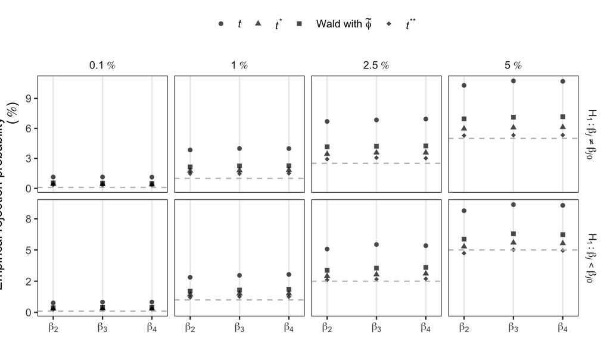

```r
ggplot(typeI %>% filter(parameter != 1, is.element(statistic,
                                              c("ml", "ml_cor", "mom",
                                                "sc_ml_cor_conv")))) +
  geom_point(aes(parameter, typeI, pch = statistic), alpha = 0.7) +
  geom_hline(aes(yintercept = level), col = "grey", lty = 2) +
  facet_grid(test ~ level_chr, labeller = label_parsed, scales = "free") +
  scale_x_continuous(name = element_blank(),
                     breaks = c(2, 3, 4),
                     limits = c(1.8, 4.2),
                     labels = c(expression(beta[2]),
                       expression(beta[3]),
                       expression(beta[4]))) +
  scale_y_continuous(name = expression(paste("Empirical rejection probability
                                             (", symbol('\045'), ")")),
                     labels = function (x) {
                       if (length(x) == 0)
                         return(character())
                       x <- round_any(x, scales:::precision(x)/100)
                       scales:::comma(x * 100)
                     }) +
  theme_bw() +
  scale_shape_manual(name = " ", values = c(16, 17, 15, 18),
              labels = c(expression(italic(t)), expression(italic(t)^list("*")),
            expression(paste("Wald with ", tilde(phi))),
            expression(italic(t)^list("**")))) +
  theme(legend.position = "top",
        panel.grid.major.y = element_blank(),
        panel.grid.minor.y = element_blank(),
        panel.grid.minor.x = element_blank(),
        strip.background = element_blank())
```

# Table 5

```r
data("babies", package = "cond")
## clogit understands only 0-1 so expand
babies_expand <- ddply(babies, ~ lull + day, function(z) {
    data.frame(y = rep(c(0, 1), c(z$r2, z$r1)))
})
## Maximum likelihood fit
babies_ml <- glm(formula = y ~ day + lull - 1,
                 family = binomial, data = babies_expand)
babies_rb <- update(babies_ml, method = "brglmFit")
## Maximum conditional likelihood fit
babies_cond <- clogit(y ~ strata(day) + lull, data = babies_expand)
ml <- coef(summary(babies_ml))["lullyes", ]
rb <- coef(summary(babies_rb))["lullyes", ]
mcl <- coef(summary(babies_cond))["lullyes", ]
r <- lrtest(update(babies_ml, . ~ . - lull),
            babies_ml)
rc <- summary(babies_cond)$logtest[1]
scorec <- summary(babies_cond)$sctest[1]
out1 <- c(
    ml = unname(ml["Estimate"]),
    rb = unname(rb["Estimate"]),
    mcl = unname(mcl["coef"]),
    wald_ml = unname(ml["z value"]),
    wald_mcl = unname(mcl["z"]),
    wald_rb = unname(rb["z value"]),
    r = unname(sign(ml["Estimate"]) * sqrt(r$Chisq[2])),
    rc = unname(sign(mcl["coef"]) * sqrt(rc)),
    wald_ml_adjusted = unname(waldi(babies_ml, which = 19)),
    wald_rb_adjusted = unname(waldi(babies_rb, which = 19)))
out2 <- c(
    ml_se = unname(ml["Std. Error"]),
    rb_se = unname(rb["Std. Error"]),
    mcl_se = unname(mcl["se(coef)"]),
    ml_p = ml["Pr(>|z|)"],
    mcl_p = mcl["Pr(>|z|)"],
    rb_p = rb["Pr(>|z|)"],
    r_p = 2 * pnorm(-abs(out1["r"])),
    rc_p = 2 * pnorm(-abs(out1["rc"])),
    cor_ml_p = 2 * pnorm(-abs(out1["wald_ml_adjusted"])),
    cor_rb_p = 2 * pnorm(-abs(out1["wald_rb_adjusted"])))
round(matrix(c(out1, out2), ncol = 10, byrow = TRUE,
             dimnames = list(NULL,
                             c("mle", "rb", "mcle", "wald_ml", "wald_mlc",
                               "wald_rb", "r", "rc", "wald_ml_adjusted",
                               "wald_rb_adjusted"))), 4)
#         mle     rb   mcle wald_ml wald_mlc wald_rb      r     rc
# [1,] 1.4324 1.1562 1.2561  1.9511   1.8307  1.7362 2.1596 2.0214
# [2,] 0.7341 0.6659 0.6861  0.0510   0.0671  0.0825 0.0308 0.0432
#      wald_ml_adjusted wald_rb_adjusted
# [1,]           1.9257           1.9064
# [2,]           0.0541           0.0566
```

# Figure 4

`babies_simulation.rda` below is the output of `babies_simulation.R` in ./code, which replicates the simulation study described in Section 9.4 of Di Caterina and Kosmidis (2019).

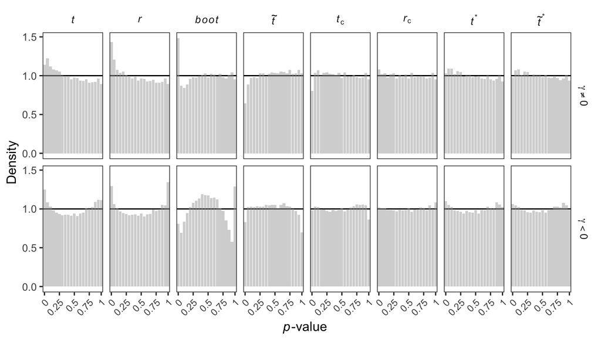

```r
load(paste(results_path, "babies_simulation.rda", sep = "/"))

## The bootstrap p-value for the babies data is
set.seed(123)
babies_bootstrap(babies_ml, R = 1000)$conv
# [1] 0.0230001
## Compute pvalues from the various statistics account for the existence of bootstrap
## p-values
pval <- ddply(res %>% filter(!infinite & !is.na(value) & type != "summary"),
              ~ name,
              function(data) {
    if (all(data$type == "bootstrap_statistic")) {
        data.frame(sample = pnorm(data$value),
                   test = gsub("boot_prep_|boot_conv_", "", data$name))
    }
    else {
        p2 <- 2 * pnorm(-abs(data$value))
        pl <- pnorm(data$value)
        pr <- 1 - pl
        data.frame(sample = c(p2, pl, pr),
                   test = rep(c("2sided", "left", "right"), each = length(p2))) }
})
## Get rid of left right 2sided from statistic names
pval <- pval %>% mutate(name = gsub("_left|_right|_2sided", "", name))
pval <- pval %>%
    filter(!(name %in% c("scorec", "boot_prep")) & test != "right") %>%
    mutate(test = dplyr::recode(test,
                                "2sided" = "gamma != 0",
                                "left" = "gamma < 0",
                                "right" = "gamma > 0"),
           name = factor(name,
                         levels = c("mle", "rbe", "r", "cond", "scorec", "rc",
                                    "boot_conv", "cor", "cor_rb"),
                         ordered = TRUE)) %>%
    mutate(name = factor(name,
                         levels = c("mle", "r", "boot_conv", "rbe",
                                    "cond", "scorec", "rc",
                                    "cor", "cor_rb"),
                         ordered = TRUE)) %>%
    mutate(statistic = dplyr::recode(name,
                                     "mle" = "italic(t)",
                                     "rbe" = "italic(tilde(t))",
                                     "r" = "italic(r)",
                                     "cond" = "italic(t)[c]",
                                     "scorec" = "italic(s)[c]",
                                     "rc" = "italic(r)[c]",
                                     "cor" = "italic(t)^'*'",
                                     "cor_rb" = "tilde(italic(t))^'*'",
                                     "boot_conv" = "italic(boot)"))
## Bin sample
breaks <- (0:20)/20
pval <- pval %>%
    group_by(statistic, test) %>%
    mutate(sample = cut(sample, breaks = breaks, include.lowest = TRUE)) %>%
    group_by(statistic, test, sample)
ggplot(pval) +
    geom_hline(aes(yintercept = 1)) +
    geom_bar(aes(x = sample, y = ..count../2500), fill = "darkgray", alpha = 0.5) +
    facet_grid(test ~ statistic, labeller = label_parsed) +
    theme_bw() +
    scale_x_discrete(breaks = c("[0,0.05]", "(0.25,0.3]", "(0.5,0.55]",
                                "(0.75,0.8]", "(0.95,1]"),
                     labels = c(0, 0.25, 0.5, 0.75, 1)) +
    theme(legend.position = "top",
          panel.grid.major.y = element_blank(),
          panel.grid.minor.y = element_blank(),
          panel.grid.minor.x = element_blank(),
          panel.grid.major.x = element_blank(),
          strip.background = element_blank(),
          axis.text.x = element_text(angle = 45, hjust = 1, size = 8)) +
    labs(x = expression(paste(italic(p), "-value ")), y = "Density")
```

# Figure 5

`brains_case_study.rda` below is the output of `brains_case_study.R` in ./code, which replicates the simulation study described in Section 10 of Di Caterina and Kosmidis (2019).

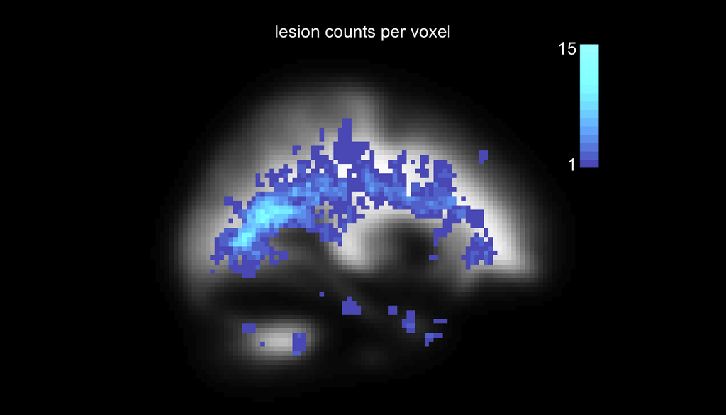

```r
source(paste0(code_path, "/", "overlay2_nifti.R"))
load(paste(results_path, "brains_case_study.rda", sep = "/"))

## Check how many times LR failed, excluding trivial voxels, and compute probability of
## infinite estimates
fits_mat %>% filter(statistic == "r" & voxel != 1) %>% group_by(parameter) %>%
    summarize(failed = 100 * sum((value == -Inf) * count) / sum(count),
              infinite = 100 * sum(infinite * count) / sum(count))
# # A tibble: 6 x 3
#   parameter failed infinite
#   <fct>      <dbl>    <dbl>
# 1 age         20.5     63.7
# 2 DD          18.1     63.7
# 3 EDSS        10.3     63.2
# 4 PASAT       16.8     63.6
# 5 sex         22.4     78.3
# 6 type2       19.2     75.5
## detections
fits_mat %>%
    group_by(parameter, statistic) %>%
    filter(statistic %in% c("z_br", "corz_br")) %>%
    summarize(detections = mean(value < -1 | value > 1) * 100)
# # A tibble: 12 x 3
# # Groups:   parameter [?]
#    parameter statistic detections
#    <fct>     <fct>          <dbl>
#  1 age       corz_br         39.2
#  2 age       z_br            33.0
#  3 DD        corz_br         24.8
#  4 DD        z_br            18.9
#  5 EDSS      corz_br         26.0
#  6 EDSS      z_br            19.8
#  7 PASAT     corz_br         37.1
#  8 PASAT     z_br            29.9
#  9 sex       corz_br         29.9
# 10 sex       z_br            22.7
# 11 type2     corz_br         22.1
# 12 type2     z_br            17.1
## Empirical lesion counts
lesion_counts <- colSums(lesions)
lesion_counts[lesion_counts == 0] <- NA
nifti_counts <- nifti(img = array(lesion_counts, dim(white_matter)))
lumin <- c(45, 100)
cols_counts <-heat_hcl(n = max(lesion_counts, na.rm = TRUE),
                       h = c(265, 200),
                       c = c(80, 50),
                       l = lumin,
                       power = c(0.7, 2))
overlay2.nifti(white_matter, y = nifti_counts, z = 32,
               plot.type = "single", plane = "sagittal",
               col.y = cols_counts, title = "lesion counts per voxel",
               col.main = "white")
```

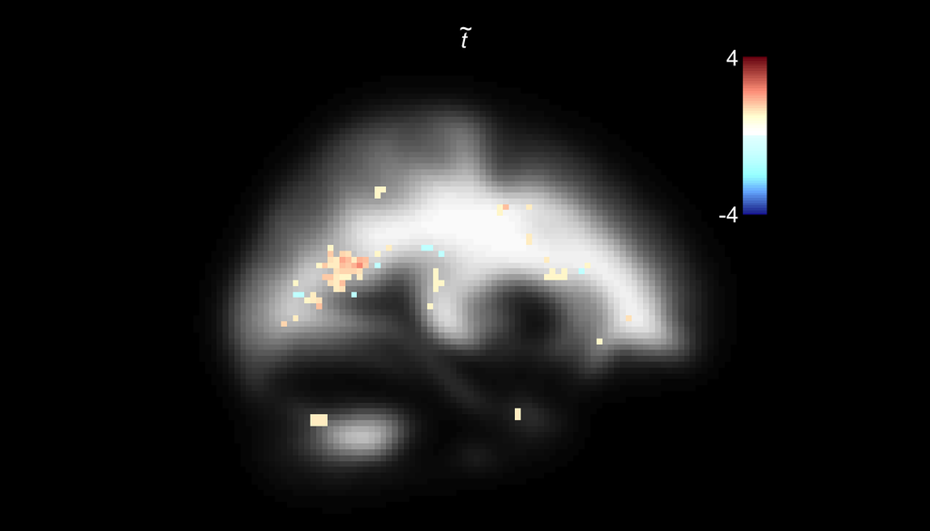

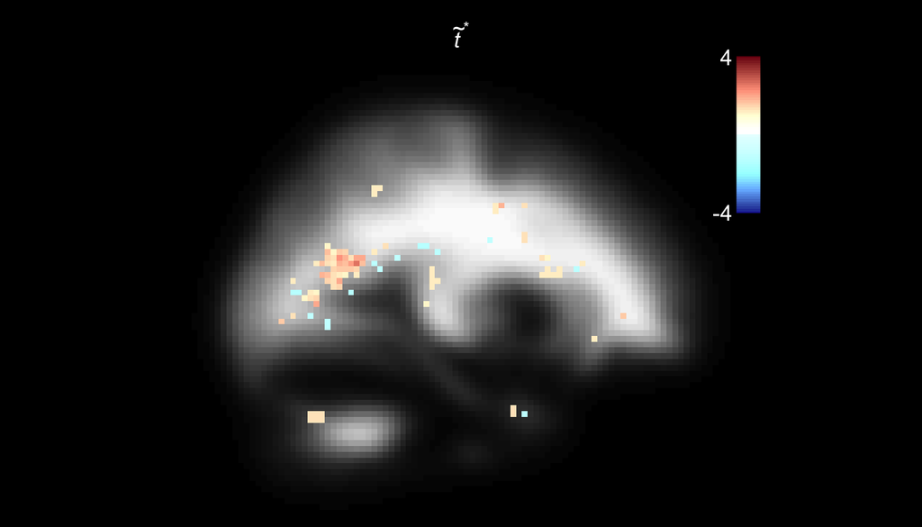

```r
## Significance maps
param <- "DD"
low <- 1
upp <- 4
lumin <- c(25, 120)
cols <- c(heat_hcl(n = 32,
                   h = c(265, 200),
                   c = c(80, 50),
                   l = lumin,
                   power = c(0.7, 2)),
          rev(heat_hcl(n = 32,
                       h = c(10, 40),
                       c = c(80, 50),
                       l = lumin,
                       power = c(0.4, 1.3))))
for (stat in c("z_br", "corz_br")) {
    zz <- (fits_mat %>% filter(statistic == stat & parameter == param))
    zz <- zz$value[array_indices]
    ## Threshold as in Ge et al (2014, AOAS)
    low_ind <- abs(zz) < low
    low_ind[is.na(low_ind)] <- FALSE
    zz[low_ind] <- NA
    upp_ind <- abs(zz) >= upp
    upp_ind[is.na(upp_ind)] <- FALSE
    zz[upp_ind] <- sign(zz[upp_ind]) * upp
    nifti_z <- nifti(img = array(zz, dim(white_matter)))
    nifti_z[1,1,1] <- -upp
    nifti_z[1,1,2] <- upp
    main <- switch(stat,
                   z_br = expression(tilde(italic(t))),
                   corz_br = expression(tilde(italic(t))^'*'))
    overlay2.nifti(white_matter, y = nifti_z, z = 32, plot.type = "single",
                   plane = "sagittal", col.y = cols, title = main,
                   col.main = "white")
}
```

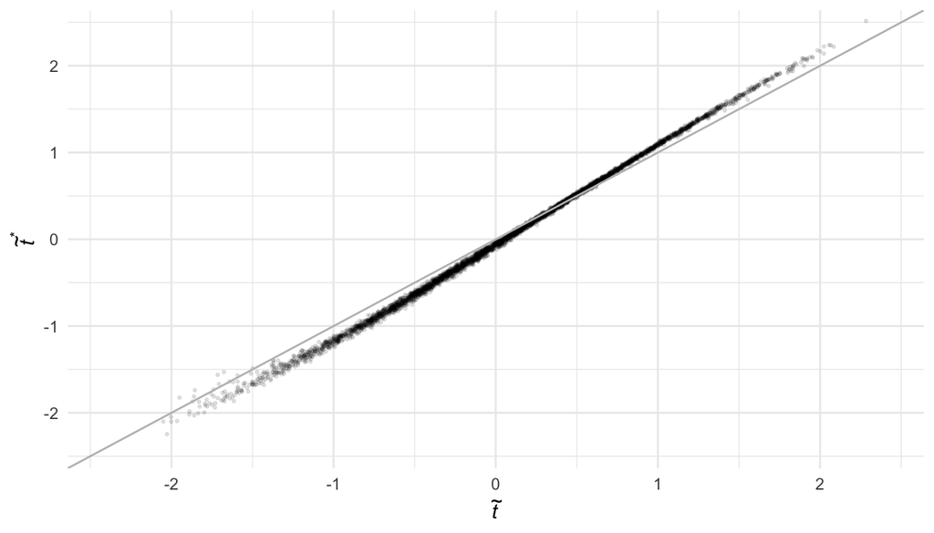

```r
### Plot z_br vs corz_br per parameter
v1 <- fits_mat %>%
    filter(statistic == "z_br", parameter == param) %>%
    select(z_br_value = value, voxel, parameter)
v2 <- fits_mat %>%
    filter(statistic == "corz_br", parameter == param) %>%
    select(corz_br_value = value, voxel, parameter)
v <- join(v1, v2, by = c("voxel", "parameter"))
ggplot(v) +
    geom_point(aes(x = z_br_value, y = corz_br_value), alpha = 0.1, size = 0.5) +
    geom_abline(aes(intercept = 0, slope = 1), col = "grey") +
    coord_cartesian(xlim = c(-2.4, 2.4), ylim = c(-2.4, 2.4)) +
    theme_minimal() +
    labs(x = expression(tilde(italic(t))), y = expression(tilde(italic(t))^'*'))
```

# Execution times

## Timings in Concluding Remarks

```r
numerical_time <- system.time(
    numerical <- waldi(babies_ml, numerical = TRUE, which = 19)
)
analytic_time <- system.time(
    analytic <- waldi(babies_ml, numerical = FALSE, which = 19)
)
(numerical_time/analytic_time)["elapsed"]
#  elapsed
# 7.206897
```

## Execution times and parallelization

`babies_times.rda` below is the output of `babies_times.R` in ./code.

The figure below shows how the execution time varies with the number of available cores, when computing the location-adjusted statistics in parallel with null value 0 for all 19 parameters in model (22) of the manuscript, using both numerical and analytical derivatives. The generally lower execution time when using analytical derivatives is also apparent.

The computation is done using the parallel implementation of the location-adjusted Wald statistics in the **waldi** R package.

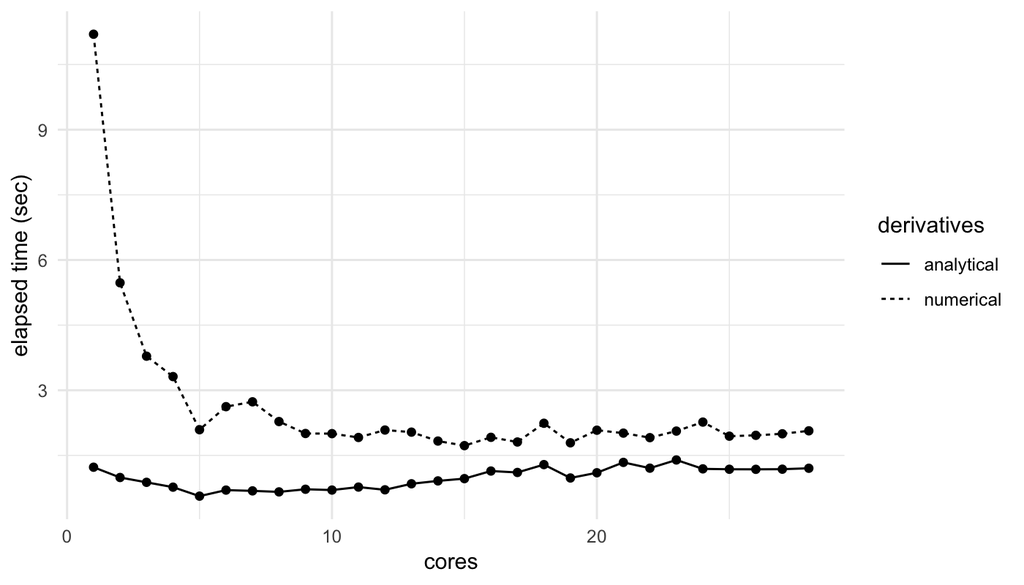

```r
load(paste(results_path, "babies_times.rda", sep = "/"))

times_ana <- sapply(out_ana, function(x) rowMeans(x)["elapsed"])
times_num <- sapply(out_num, function(x) rowMeans(x)["elapsed"])
cores <- seq_along(out_num)
res <- data.frame(times = c(times_ana, times_num),
           cores = c(cores, cores),
           derivatives = rep(c("analytical", "numerical"), each = length(cores)))

ggplot(res) +
   geom_line(aes(x = cores, y = times, lty = derivatives)) +
   geom_point(aes(x = cores, y = times)) +
   theme_minimal() +
   labs(x = "cores", y = "elapsed time (sec)")
```

# Meta-regression and meta-analysis

## Wald statistics

The random-effects meta-regression model, i.e. the extension to random-effects meta-analysis for combining information from $K$ studies about a common effect of interest (DerSimonian and Laird, 1986), assumes that $Y_1,\dots,Y_n$ are independent random variables conditionally on independent random effects $U_1,\dots,U_K$. The conditional distribution of $Y_i$ given $x_i$ and $U_i=u_i$ is $N(u_i+x_i^\top\beta, \hat{\sigma}^2_i)$, where $\hat{\sigma}^2_i$ is the known within-study variance and $u_i$ is the realization of a $N(0, \psi)$. The unknown parameters are the $k$-vector of effects $\beta$ and the between-study heterogeneity $\psi$. Note that this specification reduces to the meta-analysis model if $x_i=1$ for every $i=1,\dots,K$. The expected information matrix depends only on $\psi$ and is

$$\begin{equation}
\label{eq:infometa}
i(\psi)=\left[
\begin{array}{cc}
X^\top W(\psi) X & 0_k \\
0_k^\top & \frac{1}{2}\mathrm{tr}\big\{W(\psi)^2\big\}
\end{array}
\right]\,,
\end{equation}$$
where $W(\psi)=\mathrm{diag}\{w_1,\dots,w_n\}$, with $w_i=(\hat{\sigma}^2_i+\psi)^{-1}$. Thus, the Wald statistic for testing $H_0:\beta_j=\beta_{j0}$ takes the form $t_j = (\hat\beta_j - \beta_{j0})/\kappa_j(\hat\psi)$ $(j=1,\dots,k)$, and can be seen as the estimate of the transformation $T_j(\beta, \psi; \beta_{j0}) = (\beta_j -\beta_{j0})/\kappa_j(\psi)$, where $\kappa_j(\psi) = [\{X^\top W(\psi)X\}^{-1}]_{jj}^{1/2}$.

Guolo and Varin (2015) provide extensive evidence that Wald and other first-order likelihood-based procedures can be highly inaccurate when the number of studies is small or moderate. In these cases, Kosmidis et al. (2017) illustrate that the downward bias of the maximum likelihood estimator $\hat{\psi}$ affects conclusions on $\beta$, leading to anti-conservative tests and narrow confidence intervals, and propose asymptotic bias reduction as a means to refine first-order inference about the mean effect size.

## Implementation

The calculation of the location-adjusted Wald statistic for the simulation studies is done analytically using the formula for the first-order bias of $\hat\psi$, namely $b_\psi(\psi)=-\mathrm{tr}\{W(\psi)H(\psi)\}/\mathrm{tr}\{W(\psi)^2\}$ where $H(\psi)=X\{X^\top W(\psi)X\}^{-1}X^\top W(\psi)$ (Kosmidis et al., 2017, equation (5)), the derivatives of $T_{j}(\beta, \psi; \beta_{j0})$, and the expression of the information matrix $i(\psi)$. The partial derivatives of the latter with respect to $\beta$ are zero, while

$$\begin{equation*}
\label{eq:der1ps}
\frac{d i(\psi)}{d \psi}=\left[
\begin{array}{cc}
X^\top W'(\psi) X & 0_k \\
0_k^\top & -\sum_{i = 1}^K (\hat{\sigma}^2_i+\psi)^{-3}
\end{array}
\right]\,,
\end{equation*}$$
and
$$\begin{equation*}
\label{eq:der2ps}
\frac{d^2 i(\psi)}{d \psi^2}=\left[
\begin{array}{cc}
X^\top W''(\psi) X & 0_k \\
0_k^\top & 3\sum_{i = 1}^K (\hat{\sigma}^2_i+\psi)^{-4}
\end{array}
\right]\,,
\end{equation*}$$
where $W'(\psi)=\mathrm{diag}\{w'_1,\dots,w'_n\}$, with $w'_i=-(\hat{\sigma}^2_i+\psi)^{-2}$ and $W''(\psi)=\mathrm{diag}\{w''_1,\dots,w''_n\}$, with $w''_i=2(\hat{\sigma}^2_i+\psi)^{-3}$.

## Simulation studies

This section illustrates results of the simulations performed under the random-effects meta-analysis model using the same design as in Brockwell and Gordon (2001). In particular, the realizations $y_i$ are simulated from a meta-analysis model with $\beta = 0.5$ and variance $\hat\sigma_i+\psi$, where $\hat\sigma_i$ are independently generated from a $\chi^2_1$ distribution multiplied by 0.25 and then restricted to the interval (0.009, 0.6). The parameter $\psi$ ranges from 0 to 0.1, and the number of studies $K$ from 5 to 200. Due to long execution times, we have ran the experiment based on 10 000 Monte Carlo iterations for only those combinations of $\psi$ and $K$ which are needed to reproduce below Figure 1 of Kosmidis et al. (2017).

Note that `meta_analysis_simulation.rda` below is the output of `meta_analysis_simulation.R` in ./code.

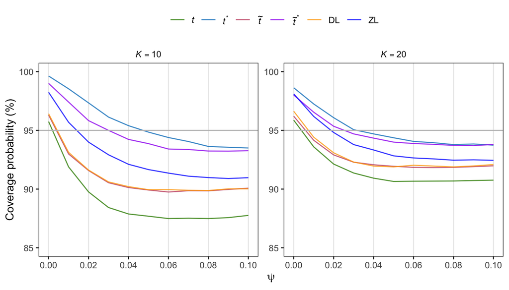

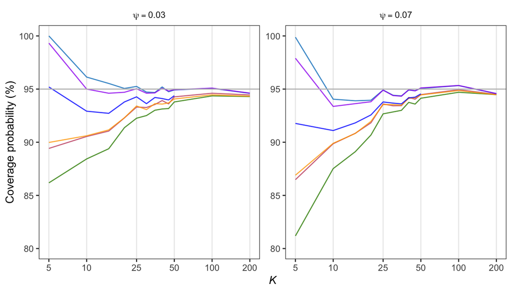

```r
load(paste(results_path, "meta_analysis_simulation.rda", sep = "/"))

## plot K = 10, 20
fig1 <- ggplot(cov_df_K  %>% filter(test == "2sided")) +
  geom_line(aes(psi, cov, group = statistic, col = statistic), size = 0.5, alpha = 0.8) +
  geom_hline(aes(yintercept = 95), col = "grey") +
  facet_wrap( ~ Klab, labeller = label_parsed, scales = "free") +
  labs(y = "Coverage probability (%)", x = expression(psi)) +
  lims(y = c(85, 100)) +
  scale_x_continuous(name = expression(psi), breaks = seq(0, 0.1, length = 6),
                     labels = c("0.00", "0.02", "0.04", "0.06", "0.08", "0.10")) +
  scale_colour_manual(name = "", values = c("#328900", "#0080C5", "#C54E6D", "purple",
        "orange", 4), labels = c(expression(italic(t)), expression(italic(t)^list("*")),
        expression(tilde(italic(t))),
        expression(tilde(italic(t))^list("*")), "DL", "ZL")) +
  theme_bw() +
  theme(legend.position = "top", panel.grid.major.y = element_blank(),
        panel.grid.minor.y = element_blank(), panel.grid.minor.x = element_blank(),
        strip.background = element_blank()) +
  guides(colour = guide_legend(nrow = 1))

## plot psi = 0.03, 0.07
fig2 <- ggplot(cov_df_psi  %>% filter(test == "2sided")) +
  geom_line(aes(log(K), cov, group = statistic, col = statistic), size = 0.5,
            alpha = 0.8) +
  geom_hline(aes(yintercept = 95), col = "grey") +
  facet_wrap( ~ psilab, labeller = label_parsed, scales = "free") +
  labs(y = "Coverage probability (%)", x = expression(italic(K))) +
  lims(y = c(80, 100)) +
  scale_x_continuous(name = expression(italic(K)), breaks = c(log(5), log(10),
                    log(25), log(50), log(100), log(200)), labels =
                      c("5", "10", "25", "50", "100", "200")) +
  scale_colour_manual(name = "", values = c("#328900", "#0080C5", "#C54E6D",
                      "purple", "orange", 4), labels = c(expression(italic(t)),
                      expression(italic(t)^list("*")), expression(tilde(italic(t))),
                      expression(tilde(italic(t))^list("*")), "DL", "ZL")) +
  theme_bw() +
  theme(legend.position = "none", panel.grid.major.y = element_blank(),
        panel.grid.minor.y = element_blank(), panel.grid.minor.x = element_blank(),
        strip.background = element_blank())
```

The last plots show the empirical coverage probabilities of individual confidence intervals for $\beta$, as $\psi$ varies when $K \in \{10, 20\}$ (top row) and as $K$ increases (in $\log$ scale) when $\psi\in \{0.03, 0.07\}$ (bottom row). The curves correspond to $t$, $t^*$, $\tilde{t}$, $\tilde{t}^*$, the Wald statistic based on the DerSimonian & Laird estimator (DL) and, for $K \leq 50$, the Zeng & Lin double-resampling method (ZL). The grey horizontal line is the target 95% nominal level.

# References

Agresti, A., and B. Caffo. 2000. “Simple and Effective Confidence Intervals for Proportions and Differences of Proportions Result from Adding Two Successes and Two Failures.” *The American Statistician* 54: 280–88.

Agresti, A., and B. A. Coull. 1998. “Approximate Is Better Than Exact for Interval Estimation of Binomial Proportions.” *The American Statistician* 52: 119–26.

Brockwell, S. E., and I. R. Gordon. 2001. “A Comparison of Statistical Methods for Meta-Analysis.” *Statistics in Medicine* 20: 825–40.

DerSimonian, R., and N. Laird. 1986. “Meta-Analysis in Clinical Trials.” *Controlled Clinical Trials* 7: 177–88.

Di Caterina, C., and I. Kosmidis. 2019. “Location-Adjusted Wald Statistics for Scalar Parameters.” *ArXiv E-Prints*. https://arxiv.org/abs/1710.11217.

Guolo, A., and C. Varin. 2015. “Random-Effects Meta-Analysis: The Number of Studies Matters.” *Statistical Methods in Medical Research* 26: 1500–1518.

Kosmidis, I., A. Guolo, and C. Varin. 2017. “Improving the Accuracy of Likelihood-Based Inference in Meta-Analysis and Meta-Regression.” *Biometrika* 104: 489–96.

R Core Team. 2017. *R: A Language and Environment for Statistical Computing*. R Foundation for Statistical Computing. https://www.R-project.org/.

Zeng, D., and D.Y. Lin. 2015. “On Random-Effects Meta-Analysis.” *Biometrika* 102: 281–94.